# Aerosol condensation process and its verification test: impact of different Gauss-Hermite quadrature points on the mass transfer coefficient

### $\color{red}{\text{Last update: 07-25-2019, test strategy, result and presentation need revision.}}$

## 1 Introduction

Condensation represents the process that the vapor of a compound condenses onto the surface of existing particle population. MAM currently considers two trace gases: sulfur acid gas ($\rm H_2SO_4$, and its condensed particles $\rm SO_4$) and a single lumped gas species of secondary organic aerosol (SOAG, and its condensed particles SOA \cite{liu-2012-gmd}).

The key parameter of condensation process is the mass transfer coefficient of species $l$ ($l \in \{ {\rm SOAG, H_2SO_4} \}$) to/from particle population (unit: $\rm s^{-1}$). By assuming that the particles are spherical and the size distribution of the particle population is described by a few log-normal modes, MAM calculates the mass transfer coefficient of species $l$ in mode $i$ ($C_{_{l,i}}$) as \cite{fuchs-1971}:

\begin{equation} \label{kmt} C_{_{l,i}} = \int_{-\infty}^{\infty} 2 \pi D_{_p} \mathbb{D}_{_{g,l}} f(K_{_{n,l}},\alpha_{_{l}}) n_{_{i}}(\ln D_{_{p}}) d\ln D_{_{p}} \,, \end{equation}

where

\begin{itemize} \item $D_{_{p}}$ is the aerosol particle diameter (unit: m); \item $n_{_{i}}(\ln D_{_{p}})$ is the log-normal size distribution of mode $i$; \item $\mathbb{D}_{_{g,l}}$ is the gas diffusivity (unit: $\rm m^2 \cdot s^{-1}$). It is calculated by \cite{fuller-1966-iec}: \begin{equation} \label{gasd} \mathbb{D}_{_{g,l}} = \frac{10^{-7}T^{1.75} \sqrt{\frac{1}{M_{_{w,l}}}+\frac{1}{M_{_{w,air}}}}} {p \left( \mathbb{V}_{_{D,l}}^\frac{1}{3}+ \mathbb{V}_{_{D,air}}^\frac{1}{3} \right)^2} \,, \end{equation} Here $T$ is air temperature (unit: K); $p$ is air pressure (unit: $\rm atm$ (the standard temperature and pressure)); $\mathbb{V}_{_{D,l}}$ (unitless) is the molecular diffusion volume; $M_{_{w,l}}$ is the molecular weight (unit: $\rm g \cdot mol^{-1}$). Both $\mathbb{V}_{_{D,l}}$ and $M_{_{w,l}}$ are constants for a given species $l$; \item $K_{_{n,l}}$ is the Knudsen number (unitless). It is calculated by: \begin{equation} \label{knu} K_{_{n,l}} = \frac{2\lambda_{_{l}}}{D_{_{p}}} \,, \end{equation} where $\lambda_{_{l}}$ is the mean free path of vapor molecules in air (unit: m) and it is calculated by: \begin{equation} \label{mfp} \lambda_{_{l}} = \frac{3\mathbb{D}_{_{g,l}}}{v_{_{l}}} \,, \end{equation} where $v_{_{l}} = \sqrt{\frac{8RT}{\pi M_{_{w,l}}}}$ is the mean speed of vapor molecules (unit: $\rm m \cdot s^{-1}$); \item $\alpha_{_{l}}$ is the accommodation coefficient (unitless), which is a constant for a given species $l$; \item $f(K_{_{n,l}}, \alpha_{_{l}})$ is a correction factor for the transition regime where the mean free path of vapor molecules is close to the particle diameter. It takes the formula below: \begin{equation} \label{fka} f(K_{_{n,l}}, \alpha_{_{l}}) = \frac{0.75 \alpha_{_{l}} (1+K_{_{n,l}})}{0.75 \alpha_{_{l}} + K_{_{n,l}} (1+K_{_{n,l}}+0.283 \alpha_{_{l}})} \,. \end{equation} \end{itemize}

Currently MAM calculates the $C_{_{H_2SO_4,i}}$ through Eq. \eqref{kmt}. Due to the large uncertainty of speciation and physical properties of SOAG/SOA, MAM assumes $C_{_{SOAG,i}} \approx 0.81 C_{_{H_2SO_4,i}}$ for simplicity. More details about the model parameterization, assumption and numerical implementation can be found in a separate model documentation. MAM uses the Gauss-Hermite quadrature rule to evaluate the Eq. \eqref{kmt}. In order to do so, changing variables is involved (the detailed derivations can be found in the appendix of a separate model documentation) and the final formula of Eq. \eqref{kmt} before using the Gauss-Hermite quadrature rule reads:

\begin{align} J(\ln D_{_p}) &= D_{_p} * f(K_{_{n,l}},\alpha_{_{l}}) \,, \\ x &= \frac{\ln D_{_p} - \left( \ln D_{_{gn,w,i}} + \beta \ln \sigma_{_{g,i}}^2 \right)} {\sqrt{2}\ln \sigma_{_{g,i}}} \,, \label{dp2x} \\ C_{_{H_2SO_4,i}} &= 2\sqrt{\pi} \mathbb{D}_{_{g,H_2SO_4}} N_{_{t,i}} \exp \left( \beta \ln D_{_{gn,w,i}} + \frac{\beta^2}{2} \ln \sigma_{_{g,i}}^2 \right) \int_{-\infty}^{\infty} \exp^{-x^2} \frac{J(\sqrt2 x \ln \sigma_{_{g,i}} + \ln D_{_{gn,w,i}} + \beta \ln \sigma_{_{g,i}}^2)}{\exp \left[ \beta \left( \sqrt2 x \sigma_{_{g,i}} + \ln D_{_{gn,w,i}} + \beta \ln \sigma_{_{g,i}}^2 \right) \right]} dx \,, \label{ghq} \\ \end{align}

where $\beta$ is an internally calculated float number between 1 and 2; $D_{_{gn,w,i}}$ and $\sigma_{_{g,i}}$ are the geometric mean wet diameter and geometric standard deviation for mode $i$.

## 2 Goals

MAM uses 2 Gauss-Hermite quadrature points to evaluate the integral in Eq. \eqref{kmt} but it remains unknown whether 2 quadrature points can provide an accurate enough solution. Thus in this test, we aim at examining the impact of different Gauss-Hermite quadrature points on the $C_{_{l,i}}$ in MAM. Since MAM assumes $C_{_{SOAG,i}} \approx 0.81 C_{_{H_2SO_4,i}}$, we then focus on the verification of $C_{_{H_2SO_4,i}}$.

## 3 Steps to establish the verification test

This verification test uses a box model that inherits the data structure and condensation subroutines from MAM in E3SM. The box model serves as a driver program to specify the necessary parameters in order to calculate the test and reference solutions.

### 3.1 Test solution

We use the condensation subroutines in MAM but 2, 4, 10, 15, 20, 30 and 40 Gauss-Hermite quadrature points to evaluate the Eq. \eqref{kmt} separately. These solutions are denoted as $C_{_{TEST}}$. The accuracy of using Gauss-Hermite quadrature rule to evaluate the integral $\int_{-\infty}^{\infty} f(x)e^{-x^2} dx$, where f(x) is a polynomial, has been verified in a separate verification test.

### 3.2 Reference solution

We use condensation subroutines in MAM and 50 Gauss-Hermite quadrature points to evaluate the Eq. \eqref{kmt}. This solution is denoted as $C_{_{REF}}$.

### 3.3 Parameters required for the verification test

In this verification test, the following quantities are specified:

\begin{enumerate} \item $\alpha_{_{H_2SO_4}} = 0.65$ \cite{poschl-1998-jpca}. \item Temperature $T$ (unit: K) and pressure $P$ (unit: Pa), for which 5 pairs of values are used to represent the typical conditions from troposphere to stratosphere: \begin{align} \rm T&: 310, 298, 273, 230, 200 \\ \rm P&: 10^5, 8.5 \times 10^4, 7 \times 10^4, 2 \times 10^4, 10^4 \end{align} \item Molecular diffusion volume $\mathbb{V}_{_{D,H_2SO_4}} = 42.88$ and $\mathbb{V}_{_{D,air}} = 20.1$ \item Molecular weight $M_{_{w,H_2SO_4}} = 98.0783997$ and $M_{_{w,air}} = 28.966$. \item Number concentration of particle population within each mode ($N_{_{t,i}}$, unit: $\# \cdot m^{-3}$). We set the values based on our previous experience and they are summarized in the table below. \item Geometric mean dry diameter ($D_{_{gn,d,i}}$, unit: $\mu m$) and geometric standard deviation ($\sigma_{_{g,i}}$) for each mode. The values of $D_{_{gn,d,i}}$ and $\sigma_{_{g,i}}$ are chosen to represent the midrange values for tropospheric aerosol observations, and are listed in the table below \cite{dick-2004-jgr}. The geometric mean wet diameter ($D_{_{gn,w,i}}$) is assumed to be 1.2 times the $D_{_{gn,d,i}}$ in this verification test for simplicity. $D_{gn,w,i}$ is the actual value used to evaluate the integral in Eq. \eqref{kmt}. \item Gauss-Hermite quadrature points ($\mathbb{R_{_i}}$) and their associated weights ($\mathbb{W_{_i}}$). They are generated using the Python function **numpy.polynomial.hermite.hermgauss** with 16 decimal digits \cite{Python-ghq}. \end{enumerate}

$$ \text{Table 1. List of typical geometric mean dry diameter ($D_{_{gn,d,i}}$), geometric standard deviation ($\sigma_{_{g,i}}$) and number concentration of } \\ \text{particle population ($N_{_{t,i}}$) for each log-normal mode.}\\ \begin{array}{c|c|c|c} \hline \text{Mode} & D_{_{gn,d,i}}, \, (\mu m) & \sigma_{_{g,i}} & N_{_{t,i}}, \, (\# \cdot m^{-3}) \\ \hline \text{Aitken} & 0.026 & 1.6 & 10^9 \\ \text{Accumulation} & 0.11 & 1.8 & 10^8 \\ \text{Coarse} & 2.0 & 1.8 & 10^5 \\ \text{Primary Carbon} & 0.05 & 1.6 & 2 \times 10^8\\ \hline \end{array} $$

With these parameters known, totally 20 (= 5(groups of T/P) × 4(modes for aerosols)) verification tests are performed.

### 3.4 PASS/FAIL criterion

In each test, the driver program calls the condensation subroutines in MAM to calculate the $C_{_{TEST}}$ and $C_{_{REF}}$. Then the relative error between $C_{_{TEST}}$ and $C_{_{REF}}$ can be calculated by:

\begin{equation} \phi = \frac{\left| C_{_{TEST}} - C_{_{REF}} \right|}{C_{_{REF}}} \end{equation}

We further perform a linear regression between number of quadrature points and $\phi$. If the slope is negative for all the 20 tests, meaning the $\phi$ decreases with more quadrature points, an overall **PASS** is then issued.

## 4 Source codes and configuration files of verification test

The verification test requires a test driver to perform the verification test and the configuration files for compilation and execution of **cmdv-test-runner** (e.g., the yaml file). If we go the root directory of **CMDV-Verification** folder that is cloned from GitHub Repo, the test driver code (**driver.F90**) is under $\rm \color{blue}{tests/mam/restructed\_tests/F90\_SRC/test\_drivers/condensation/gauss\_hermite\_convergence}$ and the yaml file is under $\rm \color{blue}{tests/mam/restructed\_tests/yaml\_files\_for\_test\_runner/condensation/gauss\_hermite\_convergence.test.yaml}$.

## 5 Verification results

If the verification test runs successfully, we should obtain the netcdf file named **"condensation_verification_test.nc"** with the mass transfer coefficient calculated by 2, 4, 10, 15, 20, 30, 40 and 50 Gauss-Hermite quadrature points. Assuming that the netcdf file is put under the **"postprocess_input"** folder, we could show the plots of $\phi$ against the number of quadrature points.

```python
# load library and modules
import numpy as np
import matplotlib.pyplot as plt
import postprocess_scripts.plot_conden_coeff as pc
#turn interactive plotting off
plt.ioff()

#define the file path and name
nc_file = "./postprocess_input/condensation_verification_test.nc"

#define output file path
outpath = "./postprocess_output/"
```

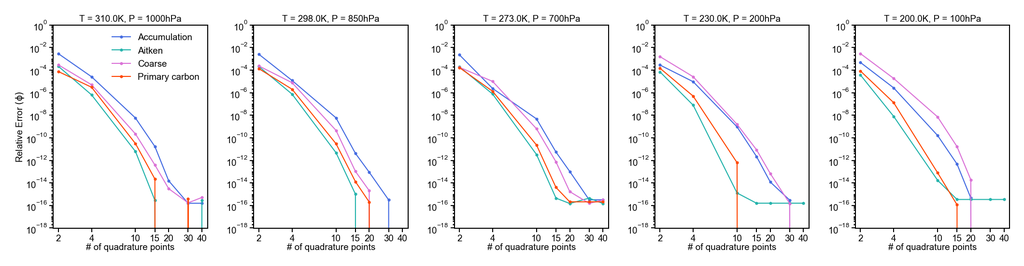

```python
#make the plot and save the figure (done in the python script)
pc.plot_coeff(nc_file, outpath, ylim=[1.e-18,1], left=0.1, right=1.2,
              top=0.45, bottom=0.1, hspace=0.4, wspace=0.3, nrows=1,
              ncols=5, fontheight=4.5, loc='upper right')
```

If a user uses the same settings in Section 3.3 and does not change the source codes, the whole output would look like:

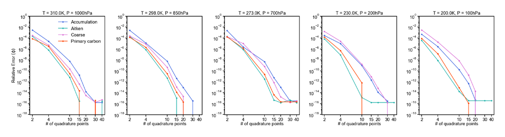

```python
pc.show_figures("./trusted_output/",left=0.1,right=2.5,top=0.9,bottom=0.1,hspace=0.1,wspace=0.1)
```

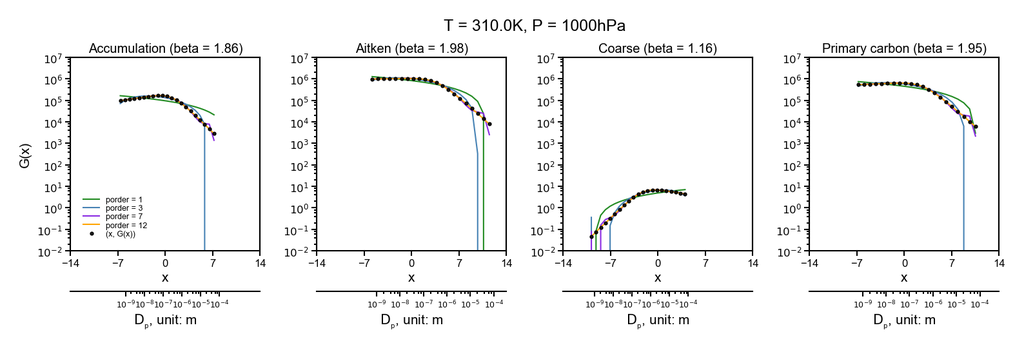

```python
# this cell does the polynomial fit to the G(x)
pc.fit_poly(nc_file, outpath, case_idx=0, porder=[1,3,7,12],
            xvalues=np.log(np.float_power(10,np.linspace(-9,-4,21))),
            colors=['forestgreen','steelblue','blueviolet','orange'],
            xlim=[-14,14], ylim=[1.e-2, 1.e7],
            xtick=np.arange(-14,21,7), ytick=np.float_power(10,np.linspace(-2,7,10)),
            yticklabel=[r'$10^{-2}$',r'$10^{-1}$',r'$10^0$',r'$10^1$',r'$10^2$',r'$10^3$', \
                        r'$10^4$',r'$10^5$',r'$10^6$',r'$10^7$'],
            left=0.1, right=0.9, top=0.35, bottom=0.1, hspace=0.7, wspace=0.3, loc=[0.05,0.05])
```

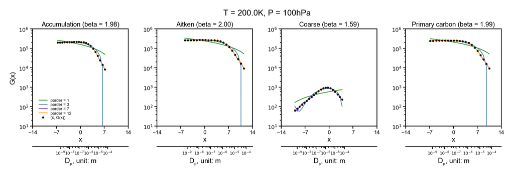

```python
# choose a different case_idx for different T/P
pc.fit_poly(nc_file, outpath, case_idx=4, porder=[1,3,7,12],
            xvalues=np.log(np.float_power(10,np.linspace(-9,-4,21))),
            colors=['forestgreen','steelblue','blueviolet','orange'],
            xlim=[-14,14], ylim=[1.e1, 1.e6],
            xtick=np.arange(-14,21,7), ytick=np.float_power(10,np.linspace(1,6,6)),
            yticklabel=[r'$10^1$',r'$10^2$',r'$10^3$',r'$10^4$',r'$10^5$',r'$10^6$'],
            left=0.1, right=0.9, top=0.35, bottom=0.1, hspace=0.7, wspace=0.3, loc=[0.05,0.05])
```

Finally we check whether a **PASS/FAIL** should be issued based on the criterion in Section 3.4.

```python
# run this cell to issue the PASS/FAIL
pc.check_rate(nc_file)
```

```
PASS
```

# References

[1] Liu X., Easter R. C., Ghan S. J. *et al.*, ``*Toward a minimal representation of aerosols in climate models: description and evaluation in the Community Atmosphere Model CAM5*'', Geoscientific Model Development, vol. 5, number 3, pp. 709--739, 2012. [online](https://www.geosci-model-dev.net/5/709/2012/)

[2] NA Fuchs and AG Sutugin, ``*High dispersed aerosols: in: Topics in current aerosol research, edited by: Hidy, GM and Brock, JR, vol. 2*'', 1971.

[3] Fuller Edward N, Schettler Paul D and Giddings J Calvin, ``*New method for prediction of binary gas-phase diffusion coefficients*'', Industrial \& Engineering Chemistry, vol. 58, number 5, pp. 18--27, 1966.

[4] P{\"o}schl Ulrich, Canagaratna Manjula, Jayne John T *et al.*, ``*Mass accommodation coefficient of H2SO4 vapor on aqueous sulfuric acid surfaces and gaseous diffusion coefficient of H2SO4 in N2/H2O*'', The Journal of Physical Chemistry A, vol. 102, number 49, pp. 10082--10089, 1998.

[5] Easter Richard C., Ghan Steven J., Zhang Yang *et al.*, ``*MIRAGE: Model description and evaluation of aerosols and trace gases*'', Journal of Geophysical Research: Atmospheres, vol. 109, number D20, pp. , 2004.

[6] , ``*Python function to generate the Gauss–Hermite quadrature points*'', . [online](https://docs.scipy.org/doc/numpy-1.13.0/reference/generated/numpy.polynomial.hermite.hermgauss.html#numpy.polynomial.hermite.hermgauss)